# STAT 413/613: HW on List Columns and COVID19

Ifebunandu Jerome Okeke

2021-04-25

# Instructions

1. Clone this homework repo to your homework directory as a new repo.
2. Rename the starter file under the analysis directory as `hw_01_yourname.Rmd` and use it for your solutions.
3. Modify the “author” field in the YAML header.
4. Stage and Commit R Markdown and HTML files (no PDF files).
5. **Push both .Rmd and HTML files to GitHub**.
- Make sure you have knitted to HTML prior to staging, committing, and pushing your final submission.
6. **Commit each time you answer a part of question, e.g. 1.1**
7. **Push to GitHub after each major question**
8. When complete, submit a response in Canvas
- Only include necessary code to answer the questions.
- Most of the functions you use should be from the tidyverse. Unnecessary Base R or other packages not covered in class will result in point deductions.
- Use Pull requests and or email to ask me any questions. If you email, please ensure your most recent code is pushed to GitHub.
- **Learning Outcome**
  - Use tidyverse functions to create, clean, tidy, and manipulate data frames in a list column
  - Apply purrr functions when working with list columns
  - Employ joins to manipulate data from multiple data frames
- **Context**
  - This assignment looks at COVID-19 data based on the most recent data as of the date you do the work.

# 1 Load global and US confirmed cases and deaths data into a nested data frame

1. Create a variable called `url_in` to store this URL: “https://raw.githubusercontent.com/CSSEGISandData/COVID-19/master/csse_covid_19_data/csse_covid_19_time_series/”. This allows you do directly download the files at the John’s Hopkins site: “https://github.com/CSSEGISandData/COVID-19/tree/master/csse_covid_19_data/csse_covid_19_time_series”

```r
library(httr)

library(tidyverse)
library(rvest)
library(purrr)
```

```r
url_in <- "https://raw.githubusercontent.com/CSSEGISandData/COVID-19/master/csse_covid_19_data/csse_covid_19_time_series/"
```

## 1.1

## 1.2

2. Create a tibble named `df` with a variable called `file_names` with a row for each of the following four file names to be loaded from the URL:
   - time_series_covid19_confirmed_global.cs
   - time_series_covid19_deaths_global.csv
   - time_series_covid19_confirmed_US.csv
   - time_series_covid19_deaths_US.csv

```r
df <- tibble(file_names = c("time_series_covid19_confirmed_global.csv", "time_series_covid19_deaths_global.csv", "time_series_covid19_confirmed_US.csv", "time_series_covid19_deaths_US.csv"), .rows = 4)
```

3. Create a variable in the data frame called `url` that puts `url_in` on the front of each file_name to create a complete URL.

```r
df %>%

  mutate(url = str_c(url_in, df$file_names))  ->

  df
```

4. Use `mutate()` with `map()` to create a list column called `data` with each row holding the downloaded data frame for each file name

```r
df <- df %>%
  mutate(data = map(.x = url, .f = ~read_csv(.x)))
```

## 1.3

## 1.4

5. Add a factor variable to `df` called `"`case_type`"` with the **unique** portions of the file names.

```r
df <- df %>%

  mutate(case_type = str_sub(file_names, 21, -5),
         case_type = as_factor(case_type))
```

6. Remove any columns other than `case_types` and `data` from `df`.
- `df` should have four observations of two variables.

```r
df %>%
  select(case_type, data) ->  df; df
```

```
## # A tibble: 4 x 2
##   case_type        data
##   <fct>            <list>
## 1 confirmed_global <spec_tbl_df [275 x 463]>
## 2 deaths_global    <spec_tbl_df [275 x 463]>
## 3 confirmed_US     <spec_tbl_df [3,342 x 470]>
## 4 deaths_US        <spec_tbl_df [3,342 x 471]>
```

# 2 2. Clean Data

1. Using a single call to `map()`, add only the first 15 names from each of the four data frames to a new variable in `df` called `vars`.
- Visually compare them to identify issues across the rows.

```r
df$vars <- map(.x = df$data, ~ (.[,1:15]))
```

2. Use a purrr function for each of the following steps (except a) to fix any issues and create consistent data frames.
1. Create a short helper function called `fix_names()` which takes three arguments: a data frame, a string pattern, and a string “replacement pattern”. It should replace all occurrences of the “string pattern” in the names of the variables in the data frame with the “replacement pattern”. Include error checking to ensure the inputs are of the proper class.

## 2.1

## 2.2

```r
fix_names <- function(df, pattern, replacement){
  stopifnot(is_tibble(df),
            is.character(pattern),
            is.character(replacement))
  if (is_tibble(df) & pattern == "[:punct:]" & replacement == "_") {
    df1 <- df %>%
      set_names(~str_replace(string = ., pattern = "[:punct:]", replacement = "_"))

    df1
  }
  else if (is_tibble(df) & pattern == "Admin2" & replacement == "County" ||
    pattern == "Long_" & replacement == "Long") {
    df2 <- df %>%
      set_names(~str_replace(string = ., pattern = "Admin2", replacement = "County")) %>%
      set_names(~str_replace(string = ., pattern = "Long_", replacement = "Long"))

    df2
  }
}
```

## 2.3

## 2.4

```r
fix_names(df$vars[[1]], "[:punct]", "_")

fix_names(df$vars[[3]], "Admin2", "County")
```

```
## # A tibble: 3,342 x 15
##         UID iso2  iso3  code3  FIPS County   Province_State Country_Region   Lat
##       <dbl> <chr> <chr> <dbl> <dbl> <chr>    <chr>          <chr>          <dbl>
##  1 84001001 US    USA     840  1001 Autauga  Alabama        US              32.5
##  2 84001003 US    USA     840  1003 Baldwin  Alabama        US              30.7
##  3 84001005 US    USA     840  1005 Barbour  Alabama        US              31.9
##  4 84001007 US    USA     840  1007 Bibb     Alabama        US              33.0
##  5 84001009 US    USA     840  1009 Blount   Alabama        US              34.0
##  6 84001011 US    USA     840  1011 Bullock  Alabama        US              32.1
##  7 84001013 US    USA     840  1013 Butler   Alabama        US              31.8
##  8 84001015 US    USA     840  1015 Calhoun  Alabama        US              33.8
##  9 84001017 US    USA     840  1017 Chambers Alabama        US              32.9
## 10 84001019 US    USA     840  1019 Cherokee Alabama        US              34.2
## # ... with 3,332 more rows, and 6 more variables: Long <dbl>,
## #   Combined_Key <chr>, 1/22/20 <dbl>, 1/23/20 <dbl>, 1/24/20 <dbl>,
## #   1/25/20 <dbl>
```

```r
fix_names(df$vars[[3]], "Long_", "Long")
```

```
## # A tibble: 3,342 x 15
##         UID iso2  iso3  code3  FIPS County   Province_State Country_Region   Lat
##       <dbl> <chr> <chr> <dbl> <dbl> <chr>    <chr>          <chr>          <dbl>
##  1 84001001 US    USA     840  1001 Autauga  Alabama        US              32.5
##  2 84001003 US    USA     840  1003 Baldwin  Alabama        US              30.7
##  3 84001005 US    USA     840  1005 Barbour  Alabama        US              31.9
##  4 84001007 US    USA     840  1007 Bibb     Alabama        US              33.0
##  5 84001009 US    USA     840  1009 Blount   Alabama        US              34.0
##  6 84001011 US    USA     840  1011 Bullock  Alabama        US              32.1
##  7 84001013 US    USA     840  1013 Butler   Alabama        US              31.8
##  8 84001015 US    USA     840  1015 Calhoun  Alabama        US              33.8
##  9 84001017 US    USA     840  1017 Chambers Alabama        US              32.9
## 10 84001019 US    USA     840  1019 Cherokee Alabama        US              34.2
## # ... with 3,332 more rows, and 6 more variables: Long <dbl>,
## #   Combined_Key <chr>, 1/22/20 <dbl>, 1/23/20 <dbl>, 1/24/20 <dbl>,
## #   1/25/20 <dbl>
```

## 2.5

## 2.6

2. Use your function with `map()` to convert “Province/State” and “Country/Region” to “Province_State” “Country_Region” .

```r
df$data <- map(df$data, ~ fix_names(., "[:punct:]", "_"))
df$vars <- map(df$vars, ~ fix_names(., "[:punct:]", "_"))
df$data
```

```
## [[1]]
## # A tibble: 275 x 463
##    Province_State     Country_Region    Lat   Long `1_22/20` `1_23/20` `1_24/20`
##    <chr>              <chr>           <dbl>  <dbl>     <dbl>     <dbl>     <dbl>
##  1 <NA>               Afghanistan      33.9  67.7          0         0         0
##  2 <NA>               Albania          41.2  20.2          0         0         0
##  3 <NA>               Algeria          28.0   1.66         0         0         0
##  4 <NA>               Andorra          42.5   1.52         0         0         0
##  5 <NA>               Angola          -11.2  17.9          0         0         0
##  6 <NA>               Antigua and Ba~  17.1 -61.8          0         0         0
##  7 <NA>               Argentina       -38.4 -63.6          0         0         0
##  8 <NA>               Armenia          40.1  45.0          0         0         0
##  9 Australian Capita~ Australia       -35.5 149.           0         0         0
## 10 New South Wales    Australia       -33.9 151.           0         0         0
## # ... with 265 more rows, and 456 more variables: 1_25/20 <dbl>, 1_26/20 <dbl>,
## #   1_27/20 <dbl>, 1_28/20 <dbl>, 1_29/20 <dbl>, 1_30/20 <dbl>, 1_31/20 <dbl>,
## #   2_1/20 <dbl>, 2_2/20 <dbl>, 2_3/20 <dbl>, 2_4/20 <dbl>, 2_5/20 <dbl>,
## #   2_6/20 <dbl>, 2_7/20 <dbl>, 2_8/20 <dbl>, 2_9/20 <dbl>, 2_10/20 <dbl>,
## #   2_11/20 <dbl>, 2_12/20 <dbl>, 2_13/20 <dbl>, 2_14/20 <dbl>, 2_15/20 <dbl>,
## #   2_16/20 <dbl>, 2_17/20 <dbl>, 2_18/20 <dbl>, 2_19/20 <dbl>, 2_20/20 <dbl>,
## #   2_21/20 <dbl>, 2_22/20 <dbl>, 2_23/20 <dbl>, 2_24/20 <dbl>, 2_25/20 <dbl>,
## #   2_26/20 <dbl>, 2_27/20 <dbl>, 2_28/20 <dbl>, 2_29/20 <dbl>, 3_1/20 <dbl>,
## #   3_2/20 <dbl>, 3_3/20 <dbl>, 3_4/20 <dbl>, 3_5/20 <dbl>, 3_6/20 <dbl>,
## #   3_7/20 <dbl>, 3_8/20 <dbl>, 3_9/20 <dbl>, 3_10/20 <dbl>, 3_11/20 <dbl>,
## #   3_12/20 <dbl>, 3_13/20 <dbl>, 3_14/20 <dbl>, 3_15/20 <dbl>, 3_16/20 <dbl>,
## #   3_17/20 <dbl>, 3_18/20 <dbl>, 3_19/20 <dbl>, 3_20/20 <dbl>, 3_21/20 <dbl>,
## #   3_22/20 <dbl>, 3_23/20 <dbl>, 3_24/20 <dbl>, 3_25/20 <dbl>, 3_26/20 <dbl>,
## #   3_27/20 <dbl>, 3_28/20 <dbl>, 3_29/20 <dbl>, 3_30/20 <dbl>, 3_31/20 <dbl>,
## #   4_1/20 <dbl>, 4_2/20 <dbl>, 4_3/20 <dbl>, 4_4/20 <dbl>, 4_5/20 <dbl>,
## #   4_6/20 <dbl>, 4_7/20 <dbl>, 4_8/20 <dbl>, 4_9/20 <dbl>, 4_10/20 <dbl>,
## #   4_11/20 <dbl>, 4_12/20 <dbl>, 4_13/20 <dbl>, 4_14/20 <dbl>, 4_15/20 <dbl>,
## #   4_16/20 <dbl>, 4_17/20 <dbl>, 4_18/20 <dbl>, 4_19/20 <dbl>, 4_20/20 <dbl>,
## #   4_21/20 <dbl>, 4_22/20 <dbl>, 4_23/20 <dbl>, 4_24/20 <dbl>, 4_25/20 <dbl>,
## #   4_26/20 <dbl>, 4_27/20 <dbl>, 4_28/20 <dbl>, 4_29/20 <dbl>, 4_30/20 <dbl>,
## #   5_1/20 <dbl>, 5_2/20 <dbl>, 5_3/20 <dbl>, ...
##
## [[2]]
## # A tibble: 275 x 463
##    Province_State     Country_Region    Lat   Long `1_22/20` `1_23/20` `1_24/20`
##    <chr>              <chr>           <dbl>  <dbl>     <dbl>     <dbl>     <dbl>
```

[output cut: 90 more lines]

```
## #   2_18/20 <dbl>, 2_19/20 <dbl>, 2_20/20 <dbl>, 2_21/20 <dbl>, 2_22/20 <dbl>,
## #   2_23/20 <dbl>, 2_24/20 <dbl>, 2_25/20 <dbl>, 2_26/20 <dbl>, 2_27/20 <dbl>,
## #   2_28/20 <dbl>, 2_29/20 <dbl>, 3_1/20 <dbl>, 3_2/20 <dbl>, 3_3/20 <dbl>,
## #   3_4/20 <dbl>, 3_5/20 <dbl>, 3_6/20 <dbl>, 3_7/20 <dbl>, 3_8/20 <dbl>,
## #   3_9/20 <dbl>, 3_10/20 <dbl>, 3_11/20 <dbl>, 3_12/20 <dbl>, 3_13/20 <dbl>,
## #   3_14/20 <dbl>, 3_15/20 <dbl>, 3_16/20 <dbl>, 3_17/20 <dbl>, 3_18/20 <dbl>,
## #   3_19/20 <dbl>, 3_20/20 <dbl>, 3_21/20 <dbl>, 3_22/20 <dbl>, 3_23/20 <dbl>,
## #   3_24/20 <dbl>, 3_25/20 <dbl>, 3_26/20 <dbl>, 3_27/20 <dbl>, 3_28/20 <dbl>,
## #   3_29/20 <dbl>, 3_30/20 <dbl>, 3_31/20 <dbl>, 4_1/20 <dbl>, 4_2/20 <dbl>,
## #   4_3/20 <dbl>, 4_4/20 <dbl>, 4_5/20 <dbl>, 4_6/20 <dbl>, 4_7/20 <dbl>,
## #   4_8/20 <dbl>, 4_9/20 <dbl>, 4_10/20 <dbl>, 4_11/20 <dbl>, 4_12/20 <dbl>,
## #   4_13/20 <dbl>, 4_14/20 <dbl>, 4_15/20 <dbl>, 4_16/20 <dbl>, 4_17/20 <dbl>,
## #   4_18/20 <dbl>, 4_19/20 <dbl>, 4_20/20 <dbl>, 4_21/20 <dbl>, 4_22/20 <dbl>,
## #   4_23/20 <dbl>, 4_24/20 <dbl>, 4_25/20 <dbl>, 4_26/20 <dbl>, 4_27/20 <dbl>,
## #   ...
```

```r
df$vars
```

```
## [[1]]
## # A tibble: 275 x 15
##    Province_State     Country_Region    Lat   Long `1_22/20` `1_23/20` `1_24/20`
##    <chr>              <chr>           <dbl>  <dbl>     <dbl>     <dbl>     <dbl>
##  1 <NA>               Afghanistan      33.9  67.7          0         0         0
##  2 <NA>               Albania          41.2  20.2          0         0         0
##  3 <NA>               Algeria          28.0   1.66         0         0         0
##  4 <NA>               Andorra          42.5   1.52         0         0         0
##  5 <NA>               Angola          -11.2  17.9          0         0         0
##  6 <NA>               Antigua and Ba~  17.1 -61.8          0         0         0
##  7 <NA>               Argentina       -38.4 -63.6          0         0         0
##  8 <NA>               Armenia          40.1  45.0          0         0         0
##  9 Australian Capita~ Australia       -35.5 149.           0         0         0
## 10 New South Wales    Australia       -33.9 151.           0         0         0
## # ... with 265 more rows, and 8 more variables: 1_25/20 <dbl>, 1_26/20 <dbl>,
## #   1_27/20 <dbl>, 1_28/20 <dbl>, 1_29/20 <dbl>, 1_30/20 <dbl>, 1_31/20 <dbl>,
## #   2_1/20 <dbl>
##
## [[2]]
## # A tibble: 275 x 15
##    Province_State     Country_Region    Lat   Long `1_22/20` `1_23/20` `1_24/20`
##    <chr>              <chr>           <dbl>  <dbl>     <dbl>     <dbl>     <dbl>
##  1 <NA>               Afghanistan      33.9  67.7          0         0         0
##  2 <NA>               Albania          41.2  20.2          0         0         0
##  3 <NA>               Algeria          28.0   1.66         0         0         0
##  4 <NA>               Andorra          42.5   1.52         0         0         0
##  5 <NA>               Angola          -11.2  17.9          0         0         0
##  6 <NA>               Antigua and Ba~  17.1 -61.8          0         0         0
##  7 <NA>               Argentina       -38.4 -63.6          0         0         0
##  8 <NA>               Armenia          40.1  45.0          0         0         0
##  9 Australian Capita~ Australia       -35.5 149.           0         0         0
## 10 New South Wales    Australia       -33.9 151.           0         0         0
## # ... with 265 more rows, and 8 more variables: 1_25/20 <dbl>, 1_26/20 <dbl>,
## #   1_27/20 <dbl>, 1_28/20 <dbl>, 1_29/20 <dbl>, 1_30/20 <dbl>, 1_31/20 <dbl>,
## #   2_1/20 <dbl>
##
## [[3]]
## # A tibble: 3,342 x 15
##         UID iso2  iso3  code3  FIPS Admin2   Province_State Country_Region   Lat
##       <dbl> <chr> <chr> <dbl> <dbl> <chr>    <chr>          <chr>          <dbl>
```

[output cut: 16 more lines]

```
##         UID iso2  iso3  code3  FIPS Admin2   Province_State Country_Region   Lat
##       <dbl> <chr> <chr> <dbl> <dbl> <chr>    <chr>          <chr>          <dbl>
##  1 84001001 US    USA     840  1001 Autauga  Alabama        US              32.5
##  2 84001003 US    USA     840  1003 Baldwin  Alabama        US              30.7
##  3 84001005 US    USA     840  1005 Barbour  Alabama        US              31.9
##  4 84001007 US    USA     840  1007 Bibb     Alabama        US              33.0
##  5 84001009 US    USA     840  1009 Blount   Alabama        US              34.0
##  6 84001011 US    USA     840  1011 Bullock  Alabama        US              32.1
##  7 84001013 US    USA     840  1013 Butler   Alabama        US              31.8
##  8 84001015 US    USA     840  1015 Calhoun  Alabama        US              33.8
##  9 84001017 US    USA     840  1017 Chambers Alabama        US              32.9
## 10 84001019 US    USA     840  1019 Cherokee Alabama        US              34.2
## # ... with 3,332 more rows, and 6 more variables: Long_ <dbl>,
## #   Combined_Key <chr>, Population <dbl>, 1_22/20 <dbl>, 1_23/20 <dbl>,
## #   1_24/20 <dbl>
```

3. Use your function with `map()` to convert “Admin2 to”County" and “Long_” to “Long”.

```r
df$data <- map(df$data, ~ fix_names(., "Admin2", "County"))
df$vars <- map(df$vars, ~ fix_names(., "Admin2", "County"))
df$data
```

```
## [[1]]
## # A tibble: 275 x 463
##    Province_State     Country_Region    Lat   Long `1_22/20` `1_23/20` `1_24/20`
##    <chr>              <chr>           <dbl>  <dbl>     <dbl>     <dbl>     <dbl>
##  1 <NA>               Afghanistan      33.9  67.7          0         0         0
##  2 <NA>               Albania          41.2  20.2          0         0         0
##  3 <NA>               Algeria          28.0   1.66         0         0         0
##  4 <NA>               Andorra          42.5   1.52         0         0         0
##  5 <NA>               Angola          -11.2  17.9          0         0         0
##  6 <NA>               Antigua and Ba~  17.1 -61.8          0         0         0
##  7 <NA>               Argentina       -38.4 -63.6          0         0         0
##  8 <NA>               Armenia          40.1  45.0          0         0         0
##  9 Australian Capita~ Australia       -35.5 149.           0         0         0
## 10 New South Wales    Australia       -33.9 151.           0         0         0
## # ... with 265 more rows, and 456 more variables: 1_25/20 <dbl>, 1_26/20 <dbl>,
## #   1_27/20 <dbl>, 1_28/20 <dbl>, 1_29/20 <dbl>, 1_30/20 <dbl>, 1_31/20 <dbl>,
## #   2_1/20 <dbl>, 2_2/20 <dbl>, 2_3/20 <dbl>, 2_4/20 <dbl>, 2_5/20 <dbl>,
## #   2_6/20 <dbl>, 2_7/20 <dbl>, 2_8/20 <dbl>, 2_9/20 <dbl>, 2_10/20 <dbl>,
## #   2_11/20 <dbl>, 2_12/20 <dbl>, 2_13/20 <dbl>, 2_14/20 <dbl>, 2_15/20 <dbl>,
## #   2_16/20 <dbl>, 2_17/20 <dbl>, 2_18/20 <dbl>, 2_19/20 <dbl>, 2_20/20 <dbl>,
## #   2_21/20 <dbl>, 2_22/20 <dbl>, 2_23/20 <dbl>, 2_24/20 <dbl>, 2_25/20 <dbl>,
## #   2_26/20 <dbl>, 2_27/20 <dbl>, 2_28/20 <dbl>, 2_29/20 <dbl>, 3_1/20 <dbl>,
## #   3_2/20 <dbl>, 3_3/20 <dbl>, 3_4/20 <dbl>, 3_5/20 <dbl>, 3_6/20 <dbl>,
## #   3_7/20 <dbl>, 3_8/20 <dbl>, 3_9/20 <dbl>, 3_10/20 <dbl>, 3_11/20 <dbl>,
## #   3_12/20 <dbl>, 3_13/20 <dbl>, 3_14/20 <dbl>, 3_15/20 <dbl>, 3_16/20 <dbl>,
## #   3_17/20 <dbl>, 3_18/20 <dbl>, 3_19/20 <dbl>, 3_20/20 <dbl>, 3_21/20 <dbl>,
## #   3_22/20 <dbl>, 3_23/20 <dbl>, 3_24/20 <dbl>, 3_25/20 <dbl>, 3_26/20 <dbl>,
## #   3_27/20 <dbl>, 3_28/20 <dbl>, 3_29/20 <dbl>, 3_30/20 <dbl>, 3_31/20 <dbl>,
## #   4_1/20 <dbl>, 4_2/20 <dbl>, 4_3/20 <dbl>, 4_4/20 <dbl>, 4_5/20 <dbl>,
## #   4_6/20 <dbl>, 4_7/20 <dbl>, 4_8/20 <dbl>, 4_9/20 <dbl>, 4_10/20 <dbl>,
## #   4_11/20 <dbl>, 4_12/20 <dbl>, 4_13/20 <dbl>, 4_14/20 <dbl>, 4_15/20 <dbl>,
## #   4_16/20 <dbl>, 4_17/20 <dbl>, 4_18/20 <dbl>, 4_19/20 <dbl>, 4_20/20 <dbl>,
## #   4_21/20 <dbl>, 4_22/20 <dbl>, 4_23/20 <dbl>, 4_24/20 <dbl>, 4_25/20 <dbl>,
## #   4_26/20 <dbl>, 4_27/20 <dbl>, 4_28/20 <dbl>, 4_29/20 <dbl>, 4_30/20 <dbl>,
## #   5_1/20 <dbl>, 5_2/20 <dbl>, 5_3/20 <dbl>, ...
##
## [[2]]
## # A tibble: 275 x 463
##    Province_State     Country_Region    Lat   Long `1_22/20` `1_23/20` `1_24/20`
##    <chr>              <chr>           <dbl>  <dbl>     <dbl>     <dbl>     <dbl>
```

[output cut: 90 more lines]

```
## #   2_18/20 <dbl>, 2_19/20 <dbl>, 2_20/20 <dbl>, 2_21/20 <dbl>, 2_22/20 <dbl>,
## #   2_23/20 <dbl>, 2_24/20 <dbl>, 2_25/20 <dbl>, 2_26/20 <dbl>, 2_27/20 <dbl>,
## #   2_28/20 <dbl>, 2_29/20 <dbl>, 3_1/20 <dbl>, 3_2/20 <dbl>, 3_3/20 <dbl>,
## #   3_4/20 <dbl>, 3_5/20 <dbl>, 3_6/20 <dbl>, 3_7/20 <dbl>, 3_8/20 <dbl>,
## #   3_9/20 <dbl>, 3_10/20 <dbl>, 3_11/20 <dbl>, 3_12/20 <dbl>, 3_13/20 <dbl>,
## #   3_14/20 <dbl>, 3_15/20 <dbl>, 3_16/20 <dbl>, 3_17/20 <dbl>, 3_18/20 <dbl>,
## #   3_19/20 <dbl>, 3_20/20 <dbl>, 3_21/20 <dbl>, 3_22/20 <dbl>, 3_23/20 <dbl>,
## #   3_24/20 <dbl>, 3_25/20 <dbl>, 3_26/20 <dbl>, 3_27/20 <dbl>, 3_28/20 <dbl>,
## #   3_29/20 <dbl>, 3_30/20 <dbl>, 3_31/20 <dbl>, 4_1/20 <dbl>, 4_2/20 <dbl>,
## #   4_3/20 <dbl>, 4_4/20 <dbl>, 4_5/20 <dbl>, 4_6/20 <dbl>, 4_7/20 <dbl>,
## #   4_8/20 <dbl>, 4_9/20 <dbl>, 4_10/20 <dbl>, 4_11/20 <dbl>, 4_12/20 <dbl>,
## #   4_13/20 <dbl>, 4_14/20 <dbl>, 4_15/20 <dbl>, 4_16/20 <dbl>, 4_17/20 <dbl>,
## #   4_18/20 <dbl>, 4_19/20 <dbl>, 4_20/20 <dbl>, 4_21/20 <dbl>, 4_22/20 <dbl>,
## #   4_23/20 <dbl>, 4_24/20 <dbl>, 4_25/20 <dbl>, 4_26/20 <dbl>, 4_27/20 <dbl>,
## #   ...
```

```r
df$vars
```

```
## [[1]]
## # A tibble: 275 x 15
##    Province_State     Country_Region    Lat   Long `1_22/20` `1_23/20` `1_24/20`
##    <chr>              <chr>           <dbl>  <dbl>     <dbl>     <dbl>     <dbl>
##  1 <NA>               Afghanistan      33.9  67.7          0         0         0
##  2 <NA>               Albania          41.2  20.2          0         0         0
##  3 <NA>               Algeria          28.0   1.66         0         0         0
##  4 <NA>               Andorra          42.5   1.52         0         0         0
##  5 <NA>               Angola          -11.2  17.9          0         0         0
##  6 <NA>               Antigua and Ba~  17.1 -61.8          0         0         0
##  7 <NA>               Argentina       -38.4 -63.6          0         0         0
##  8 <NA>               Armenia          40.1  45.0          0         0         0
##  9 Australian Capita~ Australia       -35.5 149.           0         0         0
## 10 New South Wales    Australia       -33.9 151.           0         0         0
## # ... with 265 more rows, and 8 more variables: 1_25/20 <dbl>, 1_26/20 <dbl>,
## #   1_27/20 <dbl>, 1_28/20 <dbl>, 1_29/20 <dbl>, 1_30/20 <dbl>, 1_31/20 <dbl>,
## #   2_1/20 <dbl>
##
## [[2]]
## # A tibble: 275 x 15
##    Province_State     Country_Region    Lat   Long `1_22/20` `1_23/20` `1_24/20`
##    <chr>              <chr>           <dbl>  <dbl>     <dbl>     <dbl>     <dbl>
##  1 <NA>               Afghanistan      33.9  67.7          0         0         0
##  2 <NA>               Albania          41.2  20.2          0         0         0
##  3 <NA>               Algeria          28.0   1.66         0         0         0
##  4 <NA>               Andorra          42.5   1.52         0         0         0
##  5 <NA>               Angola          -11.2  17.9          0         0         0
##  6 <NA>               Antigua and Ba~  17.1 -61.8          0         0         0
##  7 <NA>               Argentina       -38.4 -63.6          0         0         0
##  8 <NA>               Armenia          40.1  45.0          0         0         0
##  9 Australian Capita~ Australia       -35.5 149.           0         0         0
## 10 New South Wales    Australia       -33.9 151.           0         0         0
## # ... with 265 more rows, and 8 more variables: 1_25/20 <dbl>, 1_26/20 <dbl>,
## #   1_27/20 <dbl>, 1_28/20 <dbl>, 1_29/20 <dbl>, 1_30/20 <dbl>, 1_31/20 <dbl>,
## #   2_1/20 <dbl>
##
## [[3]]
## # A tibble: 3,342 x 15
##         UID iso2  iso3  code3  FIPS County   Province_State Country_Region   Lat
##       <dbl> <chr> <chr> <dbl> <dbl> <chr>    <chr>          <chr>          <dbl>
```

[output cut: 16 more lines]

```
##         UID iso2  iso3  code3  FIPS County   Province_State Country_Region   Lat
##       <dbl> <chr> <chr> <dbl> <dbl> <chr>    <chr>          <chr>          <dbl>
##  1 84001001 US    USA     840  1001 Autauga  Alabama        US              32.5
##  2 84001003 US    USA     840  1003 Baldwin  Alabama        US              30.7
##  3 84001005 US    USA     840  1005 Barbour  Alabama        US              31.9
##  4 84001007 US    USA     840  1007 Bibb     Alabama        US              33.0
##  5 84001009 US    USA     840  1009 Blount   Alabama        US              34.0
##  6 84001011 US    USA     840  1011 Bullock  Alabama        US              32.1
##  7 84001013 US    USA     840  1013 Butler   Alabama        US              31.8
##  8 84001015 US    USA     840  1015 Calhoun  Alabama        US              33.8
##  9 84001017 US    USA     840  1017 Chambers Alabama        US              32.9
## 10 84001019 US    USA     840  1019 Cherokee Alabama        US              34.2
## # ... with 3,332 more rows, and 6 more variables: Long <dbl>,
## #   Combined_Key <chr>, Population <dbl>, 1_22/20 <dbl>, 1_23/20 <dbl>,
## #   1_24/20 <dbl>
```

4. Use a purrr function to remove the variables “UID”, “iso2”, “iso3”, “code3”, “FIPS”, and “Combined_Key” from only the US data.

```r
df$data[[3]] <- keep(df$data[[3]], !(colnames(df$data[[3]]) %in% c("UID", "iso2", "iso3", "code3", "FIPS", "Combined_Key")))
df$data[[4]] <- keep(df$data[[4]], !(colnames(df$data[[4]]) %in% c("UID", "iso2", "iso3", "code3", "FIPS", "Combined_Key")))
df$data[[3]]
```

```
## # A tibble: 3,342 x 464
##    County   Province_State Country_Region   Lat  Long `1_22/20` `1_23/20`
##    <chr>    <chr>          <chr>          <dbl> <dbl>     <dbl>     <dbl>
##  1 Autauga  Alabama        US              32.5 -86.6         0         0
##  2 Baldwin  Alabama        US              30.7 -87.7         0         0
##  3 Barbour  Alabama        US              31.9 -85.4         0         0
##  4 Bibb     Alabama        US              33.0 -87.1         0         0
##  5 Blount   Alabama        US              34.0 -86.6         0         0
##  6 Bullock  Alabama        US              32.1 -85.7         0         0
##  7 Butler   Alabama        US              31.8 -86.7         0         0
##  8 Calhoun  Alabama        US              33.8 -85.8         0         0
##  9 Chambers Alabama        US              32.9 -85.4         0         0
## 10 Cherokee Alabama        US              34.2 -85.6         0         0
## # ... with 3,332 more rows, and 457 more variables: 1_24/20 <dbl>,
## #   1_25/20 <dbl>, 1_26/20 <dbl>, 1_27/20 <dbl>, 1_28/20 <dbl>, 1_29/20 <dbl>,
## #   1_30/20 <dbl>, 1_31/20 <dbl>, 2_1/20 <dbl>, 2_2/20 <dbl>, 2_3/20 <dbl>,
## #   2_4/20 <dbl>, 2_5/20 <dbl>, 2_6/20 <dbl>, 2_7/20 <dbl>, 2_8/20 <dbl>,
## #   2_9/20 <dbl>, 2_10/20 <dbl>, 2_11/20 <dbl>, 2_12/20 <dbl>, 2_13/20 <dbl>,
## #   2_14/20 <dbl>, 2_15/20 <dbl>, 2_16/20 <dbl>, 2_17/20 <dbl>, 2_18/20 <dbl>,
## #   2_19/20 <dbl>, 2_20/20 <dbl>, 2_21/20 <dbl>, 2_22/20 <dbl>, 2_23/20 <dbl>,
## #   2_24/20 <dbl>, 2_25/20 <dbl>, 2_26/20 <dbl>, 2_27/20 <dbl>, 2_28/20 <dbl>,
## #   2_29/20 <dbl>, 3_1/20 <dbl>, 3_2/20 <dbl>, 3_3/20 <dbl>, 3_4/20 <dbl>,
## #   3_5/20 <dbl>, 3_6/20 <dbl>, 3_7/20 <dbl>, 3_8/20 <dbl>, 3_9/20 <dbl>,
## #   3_10/20 <dbl>, 3_11/20 <dbl>, 3_12/20 <dbl>, 3_13/20 <dbl>, 3_14/20 <dbl>,
## #   3_15/20 <dbl>, 3_16/20 <dbl>, 3_17/20 <dbl>, 3_18/20 <dbl>, 3_19/20 <dbl>,
## #   3_20/20 <dbl>, 3_21/20 <dbl>, 3_22/20 <dbl>, 3_23/20 <dbl>, 3_24/20 <dbl>,
## #   3_25/20 <dbl>, 3_26/20 <dbl>, 3_27/20 <dbl>, 3_28/20 <dbl>, 3_29/20 <dbl>,
## #   3_30/20 <dbl>, 3_31/20 <dbl>, 4_1/20 <dbl>, 4_2/20 <dbl>, 4_3/20 <dbl>,
## #   4_4/20 <dbl>, 4_5/20 <dbl>, 4_6/20 <dbl>, 4_7/20 <dbl>, 4_8/20 <dbl>,
## #   4_9/20 <dbl>, 4_10/20 <dbl>, 4_11/20 <dbl>, 4_12/20 <dbl>, 4_13/20 <dbl>,
## #   4_14/20 <dbl>, 4_15/20 <dbl>, 4_16/20 <dbl>, 4_17/20 <dbl>, 4_18/20 <dbl>,
## #   4_19/20 <dbl>, 4_20/20 <dbl>, 4_21/20 <dbl>, 4_22/20 <dbl>, 4_23/20 <dbl>,
## #   4_24/20 <dbl>, 4_25/20 <dbl>, 4_26/20 <dbl>, 4_27/20 <dbl>, 4_28/20 <dbl>,
## #   4_29/20 <dbl>, 4_30/20 <dbl>, 5_1/20 <dbl>, 5_2/20 <dbl>, ...
```

```r
df$data[[4]]
```

```
## # A tibble: 3,342 x 465
##    County   Province_State Country_Region   Lat  Long Population `1_22/20`
##    <chr>    <chr>          <chr>          <dbl> <dbl>      <dbl>     <dbl>
##  1 Autauga  Alabama        US              32.5 -86.6      55869         0
##  2 Baldwin  Alabama        US              30.7 -87.7     223234         0
##  3 Barbour  Alabama        US              31.9 -85.4      24686         0
##  4 Bibb     Alabama        US              33.0 -87.1      22394         0
##  5 Blount   Alabama        US              34.0 -86.6      57826         0
##  6 Bullock  Alabama        US              32.1 -85.7      10101         0
##  7 Butler   Alabama        US              31.8 -86.7      19448         0
##  8 Calhoun  Alabama        US              33.8 -85.8     113605         0
##  9 Chambers Alabama        US              32.9 -85.4      33254         0
## 10 Cherokee Alabama        US              34.2 -85.6      26196         0
## # ... with 3,332 more rows, and 458 more variables: 1_23/20 <dbl>,
## #   1_24/20 <dbl>, 1_25/20 <dbl>, 1_26/20 <dbl>, 1_27/20 <dbl>, 1_28/20 <dbl>,
## #   1_29/20 <dbl>, 1_30/20 <dbl>, 1_31/20 <dbl>, 2_1/20 <dbl>, 2_2/20 <dbl>,
## #   2_3/20 <dbl>, 2_4/20 <dbl>, 2_5/20 <dbl>, 2_6/20 <dbl>, 2_7/20 <dbl>,
## #   2_8/20 <dbl>, 2_9/20 <dbl>, 2_10/20 <dbl>, 2_11/20 <dbl>, 2_12/20 <dbl>,
## #   2_13/20 <dbl>, 2_14/20 <dbl>, 2_15/20 <dbl>, 2_16/20 <dbl>, 2_17/20 <dbl>,
## #   2_18/20 <dbl>, 2_19/20 <dbl>, 2_20/20 <dbl>, 2_21/20 <dbl>, 2_22/20 <dbl>,
## #   2_23/20 <dbl>, 2_24/20 <dbl>, 2_25/20 <dbl>, 2_26/20 <dbl>, 2_27/20 <dbl>,
## #   2_28/20 <dbl>, 2_29/20 <dbl>, 3_1/20 <dbl>, 3_2/20 <dbl>, 3_3/20 <dbl>,
## #   3_4/20 <dbl>, 3_5/20 <dbl>, 3_6/20 <dbl>, 3_7/20 <dbl>, 3_8/20 <dbl>,
## #   3_9/20 <dbl>, 3_10/20 <dbl>, 3_11/20 <dbl>, 3_12/20 <dbl>, 3_13/20 <dbl>,
## #   3_14/20 <dbl>, 3_15/20 <dbl>, 3_16/20 <dbl>, 3_17/20 <dbl>, 3_18/20 <dbl>,
## #   3_19/20 <dbl>, 3_20/20 <dbl>, 3_21/20 <dbl>, 3_22/20 <dbl>, 3_23/20 <dbl>,
## #   3_24/20 <dbl>, 3_25/20 <dbl>, 3_26/20 <dbl>, 3_27/20 <dbl>, 3_28/20 <dbl>,
## #   3_29/20 <dbl>, 3_30/20 <dbl>, 3_31/20 <dbl>, 4_1/20 <dbl>, 4_2/20 <dbl>,
## #   4_3/20 <dbl>, 4_4/20 <dbl>, 4_5/20 <dbl>, 4_6/20 <dbl>, 4_7/20 <dbl>,
## #   4_8/20 <dbl>, 4_9/20 <dbl>, 4_10/20 <dbl>, 4_11/20 <dbl>, 4_12/20 <dbl>,
## #   4_13/20 <dbl>, 4_14/20 <dbl>, 4_15/20 <dbl>, 4_16/20 <dbl>, 4_17/20 <dbl>,
## #   4_18/20 <dbl>, 4_19/20 <dbl>, 4_20/20 <dbl>, 4_21/20 <dbl>, 4_22/20 <dbl>,
## #   4_23/20 <dbl>, 4_24/20 <dbl>, 4_25/20 <dbl>, 4_26/20 <dbl>, 4_27/20 <dbl>,
## #   4_28/20 <dbl>, 4_29/20 <dbl>, 4_30/20 <dbl>, 5_1/20 <dbl>, ...
```

```r
df$vars[[3]] <- keep(df$vars[[3]], !(colnames(df$vars[[3]]) %in% c("UID", "iso2", "iso3", "code3", "FIPS", "Combined_Key")))
df$vars[[4]] <- keep(df$vars[[4]], !(colnames(df$vars[[4]]) %in% c("UID", "iso2", "iso3", "code3", "FIPS", "Combined_Key")))
df$vars[[3]]
```

```
## # A tibble: 3,342 x 9
##    County   Province_State Country_Region   Lat  Long `1_22/20` `1_23/20`
##    <chr>    <chr>          <chr>          <dbl> <dbl>     <dbl>     <dbl>
##  1 Autauga  Alabama        US              32.5 -86.6         0         0
##  2 Baldwin  Alabama        US              30.7 -87.7         0         0
##  3 Barbour  Alabama        US              31.9 -85.4         0         0
##  4 Bibb     Alabama        US              33.0 -87.1         0         0
##  5 Blount   Alabama        US              34.0 -86.6         0         0
##  6 Bullock  Alabama        US              32.1 -85.7         0         0
##  7 Butler   Alabama        US              31.8 -86.7         0         0
##  8 Calhoun  Alabama        US              33.8 -85.8         0         0
##  9 Chambers Alabama        US              32.9 -85.4         0         0
## 10 Cherokee Alabama        US              34.2 -85.6         0         0
## # ... with 3,332 more rows, and 2 more variables: 1_24/20 <dbl>, 1_25/20 <dbl>
```

```r
df$vars[[4]]
```

```
## # A tibble: 3,342 x 9
##    County   Province_State Country_Region   Lat  Long Population `1_22/20`
##    <chr>    <chr>          <chr>          <dbl> <dbl>      <dbl>     <dbl>
##  1 Autauga  Alabama        US              32.5 -86.6      55869         0
##  2 Baldwin  Alabama        US              30.7 -87.7     223234         0
##  3 Barbour  Alabama        US              31.9 -85.4      24686         0
##  4 Bibb     Alabama        US              33.0 -87.1      22394         0
##  5 Blount   Alabama        US              34.0 -86.6      57826         0
##  6 Bullock  Alabama        US              32.1 -85.7      10101         0
##  7 Butler   Alabama        US              31.8 -86.7      19448         0
##  8 Calhoun  Alabama        US              33.8 -85.8     113605         0
##  9 Chambers Alabama        US              32.9 -85.4      33254         0
## 10 Cherokee Alabama        US              34.2 -85.6      26196         0
## # ... with 3,332 more rows, and 2 more variables: 1_23/20 <dbl>, 1_24/20 <dbl>
```

## 2.7

## 2.8

5. Use a purrr function to add variables `Population` and `County` to the data frames where missing.

```r
pop_cty <- function(x) {
  stopifnot(is_tibble(x))
  if (colnames(x) %>% has_element("County") == TRUE &
      colnames(x) %>% has_element("Population") == TRUE) {
    x
  }
   if (colnames(x) %>% has_element("County") == FALSE ||
           colnames(x) %>% has_element("Population") == FALSE) {
    added_var <- df$vars[[4]][,!colnames(df$vars[[4]])%in%colnames(x)]
    bind_cols(x,  added_var)
  }
}


df$data[3] <- map(df$data[3], ~pop_cty(.x))
df$data[[3]] <- df$data[[3]][c(1:5,454,6:453)]
df$data
```

```
## [[1]]
## # A tibble: 275 x 463
##    Province_State     Country_Region    Lat   Long `1_22/20` `1_23/20` `1_24/20`
##    <chr>              <chr>           <dbl>  <dbl>     <dbl>     <dbl>     <dbl>
##  1 <NA>               Afghanistan      33.9  67.7          0         0         0
##  2 <NA>               Albania          41.2  20.2          0         0         0
##  3 <NA>               Algeria          28.0   1.66         0         0         0
##  4 <NA>               Andorra          42.5   1.52         0         0         0
##  5 <NA>               Angola          -11.2  17.9          0         0         0
##  6 <NA>               Antigua and Ba~  17.1 -61.8          0         0         0
##  7 <NA>               Argentina       -38.4 -63.6          0         0         0
##  8 <NA>               Armenia          40.1  45.0          0         0         0
##  9 Australian Capita~ Australia       -35.5 149.           0         0         0
## 10 New South Wales    Australia       -33.9 151.           0         0         0
## # ... with 265 more rows, and 456 more variables: 1_25/20 <dbl>, 1_26/20 <dbl>,
## #   1_27/20 <dbl>, 1_28/20 <dbl>, 1_29/20 <dbl>, 1_30/20 <dbl>, 1_31/20 <dbl>,
## #   2_1/20 <dbl>, 2_2/20 <dbl>, 2_3/20 <dbl>, 2_4/20 <dbl>, 2_5/20 <dbl>,
## #   2_6/20 <dbl>, 2_7/20 <dbl>, 2_8/20 <dbl>, 2_9/20 <dbl>, 2_10/20 <dbl>,
## #   2_11/20 <dbl>, 2_12/20 <dbl>, 2_13/20 <dbl>, 2_14/20 <dbl>, 2_15/20 <dbl>,
## #   2_16/20 <dbl>, 2_17/20 <dbl>, 2_18/20 <dbl>, 2_19/20 <dbl>, 2_20/20 <dbl>,
## #   2_21/20 <dbl>, 2_22/20 <dbl>, 2_23/20 <dbl>, 2_24/20 <dbl>, 2_25/20 <dbl>,
## #   2_26/20 <dbl>, 2_27/20 <dbl>, 2_28/20 <dbl>, 2_29/20 <dbl>, 3_1/20 <dbl>,
## #   3_2/20 <dbl>, 3_3/20 <dbl>, 3_4/20 <dbl>, 3_5/20 <dbl>, 3_6/20 <dbl>,
## #   3_7/20 <dbl>, 3_8/20 <dbl>, 3_9/20 <dbl>, 3_10/20 <dbl>, 3_11/20 <dbl>,
## #   3_12/20 <dbl>, 3_13/20 <dbl>, 3_14/20 <dbl>, 3_15/20 <dbl>, 3_16/20 <dbl>,
## #   3_17/20 <dbl>, 3_18/20 <dbl>, 3_19/20 <dbl>, 3_20/20 <dbl>, 3_21/20 <dbl>,
## #   3_22/20 <dbl>, 3_23/20 <dbl>, 3_24/20 <dbl>, 3_25/20 <dbl>, 3_26/20 <dbl>,
## #   3_27/20 <dbl>, 3_28/20 <dbl>, 3_29/20 <dbl>, 3_30/20 <dbl>, 3_31/20 <dbl>,
## #   4_1/20 <dbl>, 4_2/20 <dbl>, 4_3/20 <dbl>, 4_4/20 <dbl>, 4_5/20 <dbl>,
## #   4_6/20 <dbl>, 4_7/20 <dbl>, 4_8/20 <dbl>, 4_9/20 <dbl>, 4_10/20 <dbl>,
## #   4_11/20 <dbl>, 4_12/20 <dbl>, 4_13/20 <dbl>, 4_14/20 <dbl>, 4_15/20 <dbl>,
## #   4_16/20 <dbl>, 4_17/20 <dbl>, 4_18/20 <dbl>, 4_19/20 <dbl>, 4_20/20 <dbl>,
## #   4_21/20 <dbl>, 4_22/20 <dbl>, 4_23/20 <dbl>, 4_24/20 <dbl>, 4_25/20 <dbl>,
## #   4_26/20 <dbl>, 4_27/20 <dbl>, 4_28/20 <dbl>, 4_29/20 <dbl>, 4_30/20 <dbl>,
## #   5_1/20 <dbl>, 5_2/20 <dbl>, 5_3/20 <dbl>, ...
##
## [[2]]
## # A tibble: 275 x 463
##    Province_State     Country_Region    Lat   Long `1_22/20` `1_23/20` `1_24/20`
##    <chr>              <chr>           <dbl>  <dbl>     <dbl>     <dbl>     <dbl>
```

[output cut: 88 more lines]

```
## #   2_18/20 <dbl>, 2_19/20 <dbl>, 2_20/20 <dbl>, 2_21/20 <dbl>, 2_22/20 <dbl>,
## #   2_23/20 <dbl>, 2_24/20 <dbl>, 2_25/20 <dbl>, 2_26/20 <dbl>, 2_27/20 <dbl>,
## #   2_28/20 <dbl>, 2_29/20 <dbl>, 3_1/20 <dbl>, 3_2/20 <dbl>, 3_3/20 <dbl>,
## #   3_4/20 <dbl>, 3_5/20 <dbl>, 3_6/20 <dbl>, 3_7/20 <dbl>, 3_8/20 <dbl>,
## #   3_9/20 <dbl>, 3_10/20 <dbl>, 3_11/20 <dbl>, 3_12/20 <dbl>, 3_13/20 <dbl>,
## #   3_14/20 <dbl>, 3_15/20 <dbl>, 3_16/20 <dbl>, 3_17/20 <dbl>, 3_18/20 <dbl>,
## #   3_19/20 <dbl>, 3_20/20 <dbl>, 3_21/20 <dbl>, 3_22/20 <dbl>, 3_23/20 <dbl>,
## #   3_24/20 <dbl>, 3_25/20 <dbl>, 3_26/20 <dbl>, 3_27/20 <dbl>, 3_28/20 <dbl>,
## #   3_29/20 <dbl>, 3_30/20 <dbl>, 3_31/20 <dbl>, 4_1/20 <dbl>, 4_2/20 <dbl>,
## #   4_3/20 <dbl>, 4_4/20 <dbl>, 4_5/20 <dbl>, 4_6/20 <dbl>, 4_7/20 <dbl>,
## #   4_8/20 <dbl>, 4_9/20 <dbl>, 4_10/20 <dbl>, 4_11/20 <dbl>, 4_12/20 <dbl>,
## #   4_13/20 <dbl>, 4_14/20 <dbl>, 4_15/20 <dbl>, 4_16/20 <dbl>, 4_17/20 <dbl>,
## #   4_18/20 <dbl>, 4_19/20 <dbl>, 4_20/20 <dbl>, 4_21/20 <dbl>, 4_22/20 <dbl>,
## #   4_23/20 <dbl>, 4_24/20 <dbl>, 4_25/20 <dbl>, 4_26/20 <dbl>, 4_27/20 <dbl>,
## #   4_28/20 <dbl>, 4_29/20 <dbl>, 4_30/20 <dbl>, 5_1/20 <dbl>, ...
```

```r
df$vars[3] <- map(df$vars[3], ~pop_cty(.x))
df$vars[[3]] <- df$vars[[3]][c(1,2,3,4,5,10,6,7,8,9)]
df$vars
```

```
## [[1]]
## # A tibble: 275 x 15
##    Province_State     Country_Region    Lat   Long `1_22/20` `1_23/20` `1_24/20`
##    <chr>              <chr>           <dbl>  <dbl>     <dbl>     <dbl>     <dbl>
##  1 <NA>               Afghanistan      33.9  67.7          0         0         0
##  2 <NA>               Albania          41.2  20.2          0         0         0
##  3 <NA>               Algeria          28.0   1.66         0         0         0
##  4 <NA>               Andorra          42.5   1.52         0         0         0
##  5 <NA>               Angola          -11.2  17.9          0         0         0
##  6 <NA>               Antigua and Ba~  17.1 -61.8          0         0         0
##  7 <NA>               Argentina       -38.4 -63.6          0         0         0
##  8 <NA>               Armenia          40.1  45.0          0         0         0
##  9 Australian Capita~ Australia       -35.5 149.           0         0         0
## 10 New South Wales    Australia       -33.9 151.           0         0         0
## # ... with 265 more rows, and 8 more variables: 1_25/20 <dbl>, 1_26/20 <dbl>,
## #   1_27/20 <dbl>, 1_28/20 <dbl>, 1_29/20 <dbl>, 1_30/20 <dbl>, 1_31/20 <dbl>,
## #   2_1/20 <dbl>
##
## [[2]]
## # A tibble: 275 x 15
##    Province_State     Country_Region    Lat   Long `1_22/20` `1_23/20` `1_24/20`
##    <chr>              <chr>           <dbl>  <dbl>     <dbl>     <dbl>     <dbl>
##  1 <NA>               Afghanistan      33.9  67.7          0         0         0
##  2 <NA>               Albania          41.2  20.2          0         0         0
##  3 <NA>               Algeria          28.0   1.66         0         0         0
##  4 <NA>               Andorra          42.5   1.52         0         0         0
##  5 <NA>               Angola          -11.2  17.9          0         0         0
##  6 <NA>               Antigua and Ba~  17.1 -61.8          0         0         0
##  7 <NA>               Argentina       -38.4 -63.6          0         0         0
##  8 <NA>               Armenia          40.1  45.0          0         0         0
##  9 Australian Capita~ Australia       -35.5 149.           0         0         0
## 10 New South Wales    Australia       -33.9 151.           0         0         0
## # ... with 265 more rows, and 8 more variables: 1_25/20 <dbl>, 1_26/20 <dbl>,
## #   1_27/20 <dbl>, 1_28/20 <dbl>, 1_29/20 <dbl>, 1_30/20 <dbl>, 1_31/20 <dbl>,
## #   2_1/20 <dbl>
##
## [[3]]
## # A tibble: 3,342 x 10
##    County   Province_State Country_Region   Lat  Long Population `1_22/20`
##    <chr>    <chr>          <chr>          <dbl> <dbl>      <dbl>     <dbl>
```

[output cut: 13 more lines]

```
## [[4]]
## # A tibble: 3,342 x 9
##    County   Province_State Country_Region   Lat  Long Population `1_22/20`
##    <chr>    <chr>          <chr>          <dbl> <dbl>      <dbl>     <dbl>
##  1 Autauga  Alabama        US              32.5 -86.6      55869         0
##  2 Baldwin  Alabama        US              30.7 -87.7     223234         0
##  3 Barbour  Alabama        US              31.9 -85.4      24686         0
##  4 Bibb     Alabama        US              33.0 -87.1      22394         0
##  5 Blount   Alabama        US              34.0 -86.6      57826         0
##  6 Bullock  Alabama        US              32.1 -85.7      10101         0
##  7 Butler   Alabama        US              31.8 -86.7      19448         0
##  8 Calhoun  Alabama        US              33.8 -85.8     113605         0
##  9 Chambers Alabama        US              32.9 -85.4      33254         0
## 10 Cherokee Alabama        US              34.2 -85.6      26196         0
## # ... with 3,332 more rows, and 2 more variables: 1_23/20 <dbl>, 1_24/20 <dbl>
```

6. Use a purrr function to add variable called `Country_State` that combines the country with the province/state while keeping the original columns.

```r
var_coty_st <- function(x){
  stopifnot(is_tibble(x))
  if (colnames(x) %>% has_element("Province_State") == TRUE &
      colnames(x) %>% has_element("Country_Region") == TRUE) {
    x %>%
      mutate(County_state = str_glue_data(., "{Country_Region}, {Province_State}"), .before = "Province_State")

      }

}
```

## 2.9

## 2.10

```r
df$data <- map(df$data, ~var_coty_st(.x))
df$data
```

```
## [[1]]
## # A tibble: 275 x 464
##    County_state   Province_State Country_Region   Lat   Long `1_22/20` `1_23/20`
##    <glue>         <chr>          <chr>          <dbl>  <dbl>     <dbl>     <dbl>
##  1 Afghanistan, ~ <NA>           Afghanistan     33.9  67.7          0         0
##  2 Albania, NA    <NA>           Albania         41.2  20.2          0         0
##  3 Algeria, NA    <NA>           Algeria         28.0   1.66         0         0
##  4 Andorra, NA    <NA>           Andorra         42.5   1.52         0         0
##  5 Angola, NA     <NA>           Angola         -11.2  17.9          0         0
##  6 Antigua and B~ <NA>           Antigua and B~  17.1 -61.8          0         0
##  7 Argentina, NA  <NA>           Argentina      -38.4 -63.6          0         0
##  8 Armenia, NA    <NA>           Armenia         40.1  45.0          0         0
##  9 Australia, Au~ Australian Ca~ Australia      -35.5 149.           0         0
## 10 Australia, Ne~ New South Wal~ Australia      -33.9 151.           0         0
## # ... with 265 more rows, and 457 more variables: 1_24/20 <dbl>, 1_25/20 <dbl>,
## #   1_26/20 <dbl>, 1_27/20 <dbl>, 1_28/20 <dbl>, 1_29/20 <dbl>, 1_30/20 <dbl>,
## #   1_31/20 <dbl>, 2_1/20 <dbl>, 2_2/20 <dbl>, 2_3/20 <dbl>, 2_4/20 <dbl>,
## #   2_5/20 <dbl>, 2_6/20 <dbl>, 2_7/20 <dbl>, 2_8/20 <dbl>, 2_9/20 <dbl>,
## #   2_10/20 <dbl>, 2_11/20 <dbl>, 2_12/20 <dbl>, 2_13/20 <dbl>, 2_14/20 <dbl>,
## #   2_15/20 <dbl>, 2_16/20 <dbl>, 2_17/20 <dbl>, 2_18/20 <dbl>, 2_19/20 <dbl>,
## #   2_20/20 <dbl>, 2_21/20 <dbl>, 2_22/20 <dbl>, 2_23/20 <dbl>, 2_24/20 <dbl>,
## #   2_25/20 <dbl>, 2_26/20 <dbl>, 2_27/20 <dbl>, 2_28/20 <dbl>, 2_29/20 <dbl>,
## #   3_1/20 <dbl>, 3_2/20 <dbl>, 3_3/20 <dbl>, 3_4/20 <dbl>, 3_5/20 <dbl>,
## #   3_6/20 <dbl>, 3_7/20 <dbl>, 3_8/20 <dbl>, 3_9/20 <dbl>, 3_10/20 <dbl>,
## #   3_11/20 <dbl>, 3_12/20 <dbl>, 3_13/20 <dbl>, 3_14/20 <dbl>, 3_15/20 <dbl>,
## #   3_16/20 <dbl>, 3_17/20 <dbl>, 3_18/20 <dbl>, 3_19/20 <dbl>, 3_20/20 <dbl>,
## #   3_21/20 <dbl>, 3_22/20 <dbl>, 3_23/20 <dbl>, 3_24/20 <dbl>, 3_25/20 <dbl>,
## #   3_26/20 <dbl>, 3_27/20 <dbl>, 3_28/20 <dbl>, 3_29/20 <dbl>, 3_30/20 <dbl>,
## #   3_31/20 <dbl>, 4_1/20 <dbl>, 4_2/20 <dbl>, 4_3/20 <dbl>, 4_4/20 <dbl>,
## #   4_5/20 <dbl>, 4_6/20 <dbl>, 4_7/20 <dbl>, 4_8/20 <dbl>, 4_9/20 <dbl>,
## #   4_10/20 <dbl>, 4_11/20 <dbl>, 4_12/20 <dbl>, 4_13/20 <dbl>, 4_14/20 <dbl>,
## #   4_15/20 <dbl>, 4_16/20 <dbl>, 4_17/20 <dbl>, 4_18/20 <dbl>, 4_19/20 <dbl>,
## #   4_20/20 <dbl>, 4_21/20 <dbl>, 4_22/20 <dbl>, 4_23/20 <dbl>, 4_24/20 <dbl>,
## #   4_25/20 <dbl>, 4_26/20 <dbl>, 4_27/20 <dbl>, 4_28/20 <dbl>, 4_29/20 <dbl>,
## #   4_30/20 <dbl>, 5_1/20 <dbl>, 5_2/20 <dbl>, ...
##
## [[2]]
## # A tibble: 275 x 464
##    County_state   Province_State Country_Region   Lat   Long `1_22/20` `1_23/20`
##    <glue>         <chr>          <chr>          <dbl>  <dbl>     <dbl>     <dbl>
```

[output cut: 88 more lines]

```
## #   2_17/20 <dbl>, 2_18/20 <dbl>, 2_19/20 <dbl>, 2_20/20 <dbl>, 2_21/20 <dbl>,
## #   2_22/20 <dbl>, 2_23/20 <dbl>, 2_24/20 <dbl>, 2_25/20 <dbl>, 2_26/20 <dbl>,
## #   2_27/20 <dbl>, 2_28/20 <dbl>, 2_29/20 <dbl>, 3_1/20 <dbl>, 3_2/20 <dbl>,
## #   3_3/20 <dbl>, 3_4/20 <dbl>, 3_5/20 <dbl>, 3_6/20 <dbl>, 3_7/20 <dbl>,
## #   3_8/20 <dbl>, 3_9/20 <dbl>, 3_10/20 <dbl>, 3_11/20 <dbl>, 3_12/20 <dbl>,
## #   3_13/20 <dbl>, 3_14/20 <dbl>, 3_15/20 <dbl>, 3_16/20 <dbl>, 3_17/20 <dbl>,
## #   3_18/20 <dbl>, 3_19/20 <dbl>, 3_20/20 <dbl>, 3_21/20 <dbl>, 3_22/20 <dbl>,
## #   3_23/20 <dbl>, 3_24/20 <dbl>, 3_25/20 <dbl>, 3_26/20 <dbl>, 3_27/20 <dbl>,
## #   3_28/20 <dbl>, 3_29/20 <dbl>, 3_30/20 <dbl>, 3_31/20 <dbl>, 4_1/20 <dbl>,
## #   4_2/20 <dbl>, 4_3/20 <dbl>, 4_4/20 <dbl>, 4_5/20 <dbl>, 4_6/20 <dbl>,
## #   4_7/20 <dbl>, 4_8/20 <dbl>, 4_9/20 <dbl>, 4_10/20 <dbl>, 4_11/20 <dbl>,
## #   4_12/20 <dbl>, 4_13/20 <dbl>, 4_14/20 <dbl>, 4_15/20 <dbl>, 4_16/20 <dbl>,
## #   4_17/20 <dbl>, 4_18/20 <dbl>, 4_19/20 <dbl>, 4_20/20 <dbl>, 4_21/20 <dbl>,
## #   4_22/20 <dbl>, 4_23/20 <dbl>, 4_24/20 <dbl>, 4_25/20 <dbl>, 4_26/20 <dbl>,
## #   4_27/20 <dbl>, 4_28/20 <dbl>, 4_29/20 <dbl>, 4_30/20 <dbl>, ...
```

```r
df$vars <- map(df$vars, ~var_coty_st(.x))
df$vars
```

```
## [[1]]
## # A tibble: 275 x 16
##    County_state   Province_State Country_Region   Lat   Long `1_22/20` `1_23/20`
##    <glue>         <chr>          <chr>          <dbl>  <dbl>     <dbl>     <dbl>
##  1 Afghanistan, ~ <NA>           Afghanistan     33.9  67.7          0         0
##  2 Albania, NA    <NA>           Albania         41.2  20.2          0         0
##  3 Algeria, NA    <NA>           Algeria         28.0   1.66         0         0
##  4 Andorra, NA    <NA>           Andorra         42.5   1.52         0         0
##  5 Angola, NA     <NA>           Angola         -11.2  17.9          0         0
##  6 Antigua and B~ <NA>           Antigua and B~  17.1 -61.8          0         0
##  7 Argentina, NA  <NA>           Argentina      -38.4 -63.6          0         0
##  8 Armenia, NA    <NA>           Armenia         40.1  45.0          0         0
##  9 Australia, Au~ Australian Ca~ Australia      -35.5 149.           0         0
## 10 Australia, Ne~ New South Wal~ Australia      -33.9 151.           0         0
## # ... with 265 more rows, and 9 more variables: 1_24/20 <dbl>, 1_25/20 <dbl>,
## #   1_26/20 <dbl>, 1_27/20 <dbl>, 1_28/20 <dbl>, 1_29/20 <dbl>, 1_30/20 <dbl>,
## #   1_31/20 <dbl>, 2_1/20 <dbl>
##
## [[2]]
## # A tibble: 275 x 16
##    County_state   Province_State Country_Region   Lat   Long `1_22/20` `1_23/20`
##    <glue>         <chr>          <chr>          <dbl>  <dbl>     <dbl>     <dbl>
##  1 Afghanistan, ~ <NA>           Afghanistan     33.9  67.7          0         0
##  2 Albania, NA    <NA>           Albania         41.2  20.2          0         0
##  3 Algeria, NA    <NA>           Algeria         28.0   1.66         0         0
##  4 Andorra, NA    <NA>           Andorra         42.5   1.52         0         0
##  5 Angola, NA     <NA>           Angola         -11.2  17.9          0         0
##  6 Antigua and B~ <NA>           Antigua and B~  17.1 -61.8          0         0
##  7 Argentina, NA  <NA>           Argentina      -38.4 -63.6          0         0
##  8 Armenia, NA    <NA>           Armenia         40.1  45.0          0         0
##  9 Australia, Au~ Australian Ca~ Australia      -35.5 149.           0         0
## 10 Australia, Ne~ New South Wal~ Australia      -33.9 151.           0         0
## # ... with 265 more rows, and 9 more variables: 1_24/20 <dbl>, 1_25/20 <dbl>,
## #   1_26/20 <dbl>, 1_27/20 <dbl>, 1_28/20 <dbl>, 1_29/20 <dbl>, 1_30/20 <dbl>,
## #   1_31/20 <dbl>, 2_1/20 <dbl>
##
## [[3]]
## # A tibble: 3,342 x 11
##    County   County_state Province_State Country_Region   Lat  Long Population
##    <chr>    <glue>       <chr>          <chr>          <dbl> <dbl>      <dbl>
```

[output cut: 14 more lines]

```
## # A tibble: 3,342 x 10
##    County   County_state Province_State Country_Region   Lat  Long Population
##    <chr>    <glue>       <chr>          <chr>          <dbl> <dbl>      <dbl>
##  1 Autauga  US, Alabama  Alabama        US              32.5 -86.6      55869
##  2 Baldwin  US, Alabama  Alabama        US              30.7 -87.7     223234
##  3 Barbour  US, Alabama  Alabama        US              31.9 -85.4      24686
##  4 Bibb     US, Alabama  Alabama        US              33.0 -87.1      22394
##  5 Blount   US, Alabama  Alabama        US              34.0 -86.6      57826
##  6 Bullock  US, Alabama  Alabama        US              32.1 -85.7      10101
##  7 Butler   US, Alabama  Alabama        US              31.8 -86.7      19448
##  8 Calhoun  US, Alabama  Alabama        US              33.8 -85.8     113605
##  9 Chambers US, Alabama  Alabama        US              32.9 -85.4      33254
## 10 Cherokee US, Alabama  Alabama        US              34.2 -85.6      26196
## # ... with 3,332 more rows, and 3 more variables: 1_22/20 <dbl>, 1_23/20 <dbl>,
## #   1_24/20 <dbl>
```

## 2.11

## 2.12

7. Update the values in `df$vars` with the new first 15 names and show the values to check for consistency in each pair of rows.
- Hint: Look at help for `map_if()`

```r
df$vars[[1]] <- (df$vars[[1]] %>% left_join(df$data[[1]]))[,1:15]
df$vars[[2]] <- (df$vars[[2]] %>% left_join(df$data[[2]]))[,1:15]
df$vars[[3]] <- (df$vars[[3]] %>% left_join(df$data[[3]]))[,1:15]
df$vars[[4]] <- (df$vars[[4]] %>% left_join(df$data[[4]]))[,1:15]
df$vars
```

```
## [[1]]
## # A tibble: 275 x 15
##    County_state   Province_State Country_Region   Lat   Long `1_22/20` `1_23/20`
##    <glue>         <chr>          <chr>          <dbl>  <dbl>     <dbl>     <dbl>
##  1 Afghanistan, ~ <NA>           Afghanistan     33.9  67.7          0         0
##  2 Albania, NA    <NA>           Albania         41.2  20.2          0         0
##  3 Algeria, NA    <NA>           Algeria         28.0   1.66         0         0
##  4 Andorra, NA    <NA>           Andorra         42.5   1.52         0         0
##  5 Angola, NA     <NA>           Angola         -11.2  17.9          0         0
##  6 Antigua and B~ <NA>           Antigua and B~  17.1 -61.8          0         0
##  7 Argentina, NA  <NA>           Argentina      -38.4 -63.6          0         0
##  8 Armenia, NA    <NA>           Armenia         40.1  45.0          0         0
##  9 Australia, Au~ Australian Ca~ Australia      -35.5 149.           0         0
## 10 Australia, Ne~ New South Wal~ Australia      -33.9 151.           0         0
## # ... with 265 more rows, and 8 more variables: 1_24/20 <dbl>, 1_25/20 <dbl>,
## #   1_26/20 <dbl>, 1_27/20 <dbl>, 1_28/20 <dbl>, 1_29/20 <dbl>, 1_30/20 <dbl>,
## #   1_31/20 <dbl>
##
## [[2]]
## # A tibble: 275 x 15
##    County_state   Province_State Country_Region   Lat   Long `1_22/20` `1_23/20`
##    <glue>         <chr>          <chr>          <dbl>  <dbl>     <dbl>     <dbl>
##  1 Afghanistan, ~ <NA>           Afghanistan     33.9  67.7          0         0
##  2 Albania, NA    <NA>           Albania         41.2  20.2          0         0
##  3 Algeria, NA    <NA>           Algeria         28.0   1.66         0         0
##  4 Andorra, NA    <NA>           Andorra         42.5   1.52         0         0
##  5 Angola, NA     <NA>           Angola         -11.2  17.9          0         0
##  6 Antigua and B~ <NA>           Antigua and B~  17.1 -61.8          0         0
##  7 Argentina, NA  <NA>           Argentina      -38.4 -63.6          0         0
##  8 Armenia, NA    <NA>           Armenia         40.1  45.0          0         0
##  9 Australia, Au~ Australian Ca~ Australia      -35.5 149.           0         0
## 10 Australia, Ne~ New South Wal~ Australia      -33.9 151.           0         0
## # ... with 265 more rows, and 8 more variables: 1_24/20 <dbl>, 1_25/20 <dbl>,
## #   1_26/20 <dbl>, 1_27/20 <dbl>, 1_28/20 <dbl>, 1_29/20 <dbl>, 1_30/20 <dbl>,
## #   1_31/20 <dbl>
##
## [[3]]
## # A tibble: 3,342 x 15
##    County   County_state Province_State Country_Region   Lat  Long Population
##    <chr>    <glue>       <chr>          <chr>          <dbl> <dbl>      <dbl>
```

[output cut: 16 more lines]

```
##    County   County_state Province_State Country_Region   Lat  Long Population
##    <chr>    <glue>       <chr>          <chr>          <dbl> <dbl>      <dbl>
##  1 Autauga  US, Alabama  Alabama        US              32.5 -86.6      55869
##  2 Baldwin  US, Alabama  Alabama        US              30.7 -87.7     223234
##  3 Barbour  US, Alabama  Alabama        US              31.9 -85.4      24686
##  4 Bibb     US, Alabama  Alabama        US              33.0 -87.1      22394
##  5 Blount   US, Alabama  Alabama        US              34.0 -86.6      57826
##  6 Bullock  US, Alabama  Alabama        US              32.1 -85.7      10101
##  7 Butler   US, Alabama  Alabama        US              31.8 -86.7      19448
##  8 Calhoun  US, Alabama  Alabama        US              33.8 -85.8     113605
##  9 Chambers US, Alabama  Alabama        US              32.9 -85.4      33254
## 10 Cherokee US, Alabama  Alabama        US              34.2 -85.6      26196
## # ... with 3,332 more rows, and 8 more variables: 1_22/20 <dbl>, 1_23/20 <dbl>,
## #   1_24/20 <dbl>, 1_25/20 <dbl>, 1_26/20 <dbl>, 1_27/20 <dbl>, 1_28/20 <dbl>,
## #   1_29/20 <dbl>
```

# 3 Tidy each dataframe

1. Use `map()` along with `pivot_longer()` to tidy each data frame.
- As part of the pivot, ensure the daily values are in a variable called “`Date`” and use a lubridate function *inside the pivot* to ensure it is of class `date`.
2. Save the new data frame to a variable called `df_long`

```r
library(lubridate)
```

```r
map(.x = df$data, ~.x %>% pivot_longer(cols = str_subset(colnames(.), "^\\d"),
                      names_to = "Date",
                      values_to = "Daily_Values",
                      names_transform = list(Date = mdy))) ->
  df$df_long


df$df_long
```

```
## [[1]]
## # A tibble: 126,225 x 7
##    County_state    Province_State Country_Region   Lat  Long Date
##    <glue>          <chr>          <chr>          <dbl> <dbl> <date>
##  1 Afghanistan, NA <NA>           Afghanistan     33.9  67.7 2020-01-22
##  2 Afghanistan, NA <NA>           Afghanistan     33.9  67.7 2020-01-23
##  3 Afghanistan, NA <NA>           Afghanistan     33.9  67.7 2020-01-24
##  4 Afghanistan, NA <NA>           Afghanistan     33.9  67.7 2020-01-25
##  5 Afghanistan, NA <NA>           Afghanistan     33.9  67.7 2020-01-26
##  6 Afghanistan, NA <NA>           Afghanistan     33.9  67.7 2020-01-27
##  7 Afghanistan, NA <NA>           Afghanistan     33.9  67.7 2020-01-28
##  8 Afghanistan, NA <NA>           Afghanistan     33.9  67.7 2020-01-29
##  9 Afghanistan, NA <NA>           Afghanistan     33.9  67.7 2020-01-30
## 10 Afghanistan, NA <NA>           Afghanistan     33.9  67.7 2020-01-31
## # ... with 126,215 more rows, and 1 more variable: Daily_Values <dbl>
##
## [[2]]
## # A tibble: 126,225 x 7
##    County_state    Province_State Country_Region   Lat  Long Date
##    <glue>          <chr>          <chr>          <dbl> <dbl> <date>
##  1 Afghanistan, NA <NA>           Afghanistan     33.9  67.7 2020-01-22
##  2 Afghanistan, NA <NA>           Afghanistan     33.9  67.7 2020-01-23
##  3 Afghanistan, NA <NA>           Afghanistan     33.9  67.7 2020-01-24
##  4 Afghanistan, NA <NA>           Afghanistan     33.9  67.7 2020-01-25
##  5 Afghanistan, NA <NA>           Afghanistan     33.9  67.7 2020-01-26
##  6 Afghanistan, NA <NA>           Afghanistan     33.9  67.7 2020-01-27
##  7 Afghanistan, NA <NA>           Afghanistan     33.9  67.7 2020-01-28
##  8 Afghanistan, NA <NA>           Afghanistan     33.9  67.7 2020-01-29
##  9 Afghanistan, NA <NA>           Afghanistan     33.9  67.7 2020-01-30
## 10 Afghanistan, NA <NA>           Afghanistan     33.9  67.7 2020-01-31
## # ... with 126,215 more rows, and 1 more variable: Daily_Values <dbl>
##
## [[3]]
## # A tibble: 1,500,558 x 8
##    County  County_state Province_State Country_Region   Lat  Long Date
##    <chr>   <glue>       <chr>          <chr>          <dbl> <dbl> <date>
##  1 Autauga US, Alabama  Alabama        US              32.5 -86.6 2021-04-14
##  2 Autauga US, Alabama  Alabama        US              32.5 -86.6 2020-01-22
##  3 Autauga US, Alabama  Alabama        US              32.5 -86.6 2020-01-23
##  4 Autauga US, Alabama  Alabama        US              32.5 -86.6 2020-01-24
```

[output cut: 9 more lines]

```
## # A tibble: 1,533,978 x 9
##    County  County_state Province_State Country_Region   Lat  Long Population
##    <chr>   <glue>       <chr>          <chr>          <dbl> <dbl>      <dbl>
##  1 Autauga US, Alabama  Alabama        US              32.5 -86.6      55869
##  2 Autauga US, Alabama  Alabama        US              32.5 -86.6      55869
##  3 Autauga US, Alabama  Alabama        US              32.5 -86.6      55869
##  4 Autauga US, Alabama  Alabama        US              32.5 -86.6      55869
##  5 Autauga US, Alabama  Alabama        US              32.5 -86.6      55869
##  6 Autauga US, Alabama  Alabama        US              32.5 -86.6      55869
##  7 Autauga US, Alabama  Alabama        US              32.5 -86.6      55869
##  8 Autauga US, Alabama  Alabama        US              32.5 -86.6      55869
##  9 Autauga US, Alabama  Alabama        US              32.5 -86.6      55869
## 10 Autauga US, Alabama  Alabama        US              32.5 -86.6      55869
## # ... with 1,533,968 more rows, and 2 more variables: Date <date>,
## #   Daily_Values <dbl>
```

# 4

# 5 Add Continents

1. Use `map()` to add a new variable called `Continent` to each data frame.
- Hint: use the package {countrycode} to get the continents.
- If you don’t have it already, use the console to install.
- Then load package {countrycode} and look at help for `countrycode::countrycode`
- You will get some warning messages about NAs which you will fix next.

```r
library(countrycode)

df$df_long <- map(df$df_long, ~.x %>% mutate(Continent = countrycode(Country_Region,
                                                       origin = "country.name",
                                                       destination = "continent")))
```

```
## Warning in countrycode(Country_Region, origin = "country.name", destination = "continent"): Some values were not matched unambiguously: Diamond Princess, Kosovo, Micronesia, MS Zaandam

## Warning in countrycode(Country_Region, origin = "country.name", destination = "continent"): Some values were not matched unambiguously: Diamond Princess, Kosovo, Micronesia, MS Zaandam
```

```r
df$df_long
```

```
## [[1]]
## # A tibble: 126,225 x 8
##    County_state    Province_State Country_Region   Lat  Long Date
##    <glue>          <chr>          <chr>          <dbl> <dbl> <date>
##  1 Afghanistan, NA <NA>           Afghanistan     33.9  67.7 2020-01-22
##  2 Afghanistan, NA <NA>           Afghanistan     33.9  67.7 2020-01-23
##  3 Afghanistan, NA <NA>           Afghanistan     33.9  67.7 2020-01-24
##  4 Afghanistan, NA <NA>           Afghanistan     33.9  67.7 2020-01-25
##  5 Afghanistan, NA <NA>           Afghanistan     33.9  67.7 2020-01-26
##  6 Afghanistan, NA <NA>           Afghanistan     33.9  67.7 2020-01-27
##  7 Afghanistan, NA <NA>           Afghanistan     33.9  67.7 2020-01-28
##  8 Afghanistan, NA <NA>           Afghanistan     33.9  67.7 2020-01-29
##  9 Afghanistan, NA <NA>           Afghanistan     33.9  67.7 2020-01-30
## 10 Afghanistan, NA <NA>           Afghanistan     33.9  67.7 2020-01-31
## # ... with 126,215 more rows, and 2 more variables: Daily_Values <dbl>,
## #   Continent <chr>
##
## [[2]]
## # A tibble: 126,225 x 8
##    County_state    Province_State Country_Region   Lat  Long Date
##    <glue>          <chr>          <chr>          <dbl> <dbl> <date>
##  1 Afghanistan, NA <NA>           Afghanistan     33.9  67.7 2020-01-22
##  2 Afghanistan, NA <NA>           Afghanistan     33.9  67.7 2020-01-23
##  3 Afghanistan, NA <NA>           Afghanistan     33.9  67.7 2020-01-24
##  4 Afghanistan, NA <NA>           Afghanistan     33.9  67.7 2020-01-25
##  5 Afghanistan, NA <NA>           Afghanistan     33.9  67.7 2020-01-26
##  6 Afghanistan, NA <NA>           Afghanistan     33.9  67.7 2020-01-27
##  7 Afghanistan, NA <NA>           Afghanistan     33.9  67.7 2020-01-28
##  8 Afghanistan, NA <NA>           Afghanistan     33.9  67.7 2020-01-29
##  9 Afghanistan, NA <NA>           Afghanistan     33.9  67.7 2020-01-30
## 10 Afghanistan, NA <NA>           Afghanistan     33.9  67.7 2020-01-31
## # ... with 126,215 more rows, and 2 more variables: Daily_Values <dbl>,
## #   Continent <chr>
##
## [[3]]
## # A tibble: 1,500,558 x 9
##    County  County_state Province_State Country_Region   Lat  Long Date
##    <chr>   <glue>       <chr>          <chr>          <dbl> <dbl> <date>
##  1 Autauga US, Alabama  Alabama        US              32.5 -86.6 2021-04-14
##  2 Autauga US, Alabama  Alabama        US              32.5 -86.6 2020-01-22
```

[output cut: 12 more lines]

```
## # A tibble: 1,533,978 x 10
##    County  County_state Province_State Country_Region   Lat  Long Population
##    <chr>   <glue>       <chr>          <chr>          <dbl> <dbl>      <dbl>
##  1 Autauga US, Alabama  Alabama        US              32.5 -86.6      55869
##  2 Autauga US, Alabama  Alabama        US              32.5 -86.6      55869
##  3 Autauga US, Alabama  Alabama        US              32.5 -86.6      55869
##  4 Autauga US, Alabama  Alabama        US              32.5 -86.6      55869
##  5 Autauga US, Alabama  Alabama        US              32.5 -86.6      55869
##  6 Autauga US, Alabama  Alabama        US              32.5 -86.6      55869
##  7 Autauga US, Alabama  Alabama        US              32.5 -86.6      55869
##  8 Autauga US, Alabama  Alabama        US              32.5 -86.6      55869
##  9 Autauga US, Alabama  Alabama        US              32.5 -86.6      55869
## 10 Autauga US, Alabama  Alabama        US              32.5 -86.6      55869
## # ... with 1,533,968 more rows, and 3 more variables: Date <date>,
## #   Daily_Values <dbl>, Continent <chr>
```

# 6 Fix NAs for Continents

- Use `map()` with `case_when()` to replace the NAs due to “Diamond Princess”, “Kosovo”, “MS Zaandam” and Micronesia, with the most appropriate continent
- Use `map()` with `unique()` to confirm five continents in the global data frames and one in the US data frames

```r
df$df_long <- map(df$df_long, ~.x %>% mutate(Continent = case_when(Country_Region == "Diamond Princess"~"Europe",
                                                     Country_Region == "Kosovo"~"Europe",
                                                     Country_Region == "Micronesia"~"Oceania",
                                                     Country_Region == "MS Zaandam"~"Europe",
                                                     TRUE ~ Continent)))
```

## 6.1

## 6.2

```r
map(df$df_long, ~.x %>% select(Continent) %>% unique())
```

```
## [[1]]
## # A tibble: 5 x 1
##   Continent
##   <chr>
## 1 Asia
## 2 Europe
## 3 Africa
## 4 Americas
## 5 Oceania
##
## [[2]]
## # A tibble: 5 x 1
##   Continent
##   <chr>
## 1 Asia
## 2 Europe
## 3 Africa
## 4 Americas
## 5 Oceania
##
## [[3]]
## # A tibble: 1 x 1
##   Continent
##   <chr>
## 1 Americas
##
## [[4]]
## # A tibble: 1 x 1
##   Continent
##   <chr>
## 1 Americas
```

## 6.3

## 6.4

# 7 Unnest the Data Frames

1. Unnest and ungroup the data frame `df_long` and save into a new data frame called `df_all`

```r
 unnest(data = df, df_long) %>%
   ungroup() -> df_all

head(df_all)
```

```
## # A tibble: 6 x 13
##   case_type  data   vars  County_state Province_State Country_Region   Lat  Long
##   <fct>      <list> <lis> <glue>       <chr>          <chr>          <dbl> <dbl>
## 1 confirmed~ <tibb~ <tib~ Afghanistan~ <NA>           Afghanistan     33.9  67.7
## 2 confirmed~ <tibb~ <tib~ Afghanistan~ <NA>           Afghanistan     33.9  67.7
## 3 confirmed~ <tibb~ <tib~ Afghanistan~ <NA>           Afghanistan     33.9  67.7
## 4 confirmed~ <tibb~ <tib~ Afghanistan~ <NA>           Afghanistan     33.9  67.7
## 5 confirmed~ <tibb~ <tib~ Afghanistan~ <NA>           Afghanistan     33.9  67.7
## 6 confirmed~ <tibb~ <tib~ Afghanistan~ <NA>           Afghanistan     33.9  67.7
## # ... with 5 more variables: Date <date>, Daily_Values <dbl>, Continent <chr>,
## #   County <chr>, Population <dbl>
```

2. Remove original `df` and `df_long` dataframes from the environment

```r
rm("df")
```

3. Remove the `vars` variable from df_all

```r
df_all$vars <- NULL

head(df_all)
```

```
## # A tibble: 6 x 12
##   case_type    data       County_state Province_State Country_Region   Lat  Long
##   <fct>        <list>     <glue>       <chr>          <chr>          <dbl> <dbl>
## 1 confirmed_g~ <tibble [~ Afghanistan~ <NA>           Afghanistan     33.9  67.7
## 2 confirmed_g~ <tibble [~ Afghanistan~ <NA>           Afghanistan     33.9  67.7
## 3 confirmed_g~ <tibble [~ Afghanistan~ <NA>           Afghanistan     33.9  67.7
## 4 confirmed_g~ <tibble [~ Afghanistan~ <NA>           Afghanistan     33.9  67.7
## 5 confirmed_g~ <tibble [~ Afghanistan~ <NA>           Afghanistan     33.9  67.7
## 6 confirmed_g~ <tibble [~ Afghanistan~ <NA>           Afghanistan     33.9  67.7
## # ... with 5 more variables: Date <date>, Daily_Values <dbl>, Continent <chr>,
## #   County <chr>, Population <dbl>
```

# 8 Get World Population Data

1.a. Use a readr function and relative path to read in the .csv with World population data for 2019 into its own data frame called `df_pop`.

- The data is from the [UN](https://population.un.org/wpp/Download/Standard/CSV/) which uses different country names in many cases from the COVID data. It also uses a different structure for separating countries and territories.
- The CSV has been adjusted to match the COVID data country names in many cases, e.g., US, and Iran.
- Note: the UN population data is in thousands so it can have fractional values.

```r
df_pop <- read.csv("data/WPP2019_TotalPopulation.csv")
```

1.b. Identify the countries in the Covid data that are not in the population data.

```r
df_all %>%
  anti_join(df_pop, by = c("Country_Region" = "Location")) %>%
  group_by(Country_Region) %>%
  summarise(count = n())
```

```
## # A tibble: 3 x 2
##   Country_Region   count
##   <chr>            <int>
## 1 Diamond Princess   918
## 2 Kosovo             918
## 3 MS Zaandam         918
```

1.c. Identify the countries in the population data that are not in the covid data. How many are there?

```r
df_pop %>%

  anti_join(df_all, by = c("Location" = "Country_Region")) %>%

  group_by(Location) %>%

  summarise(count = n())
```

```
## # A tibble: 46 x 2
##    Location                         count
##    <chr>                            <int>
##  1 American Samoa                       1
##  2 Anguilla                             1
##  3 Aruba                                1
##  4 Bonaire, Sint Eustatius and Saba     1
##  5 British Virgin Islands               1
##  6 Cayman Islands                       1
##  7 Channel Islands                      1
##  8 China_Hong Kong                      1
##  9 China_Macau                          1
## 10 Cook Islands                         1
## # ... with 36 more rows
```

1.d. What is the percentage of the world population contained in these countries?

```r
df_pop %>%
  anti_join(df_all, by = c("Location"="Country_Region"))%>%
  group_by(Location) %>%
  ungroup() %>%
  summarise(sum(PopTotal))-> small

df_pop %>%
  summarise(sum(PopTotal))->large

paste0((small[[1]]/large[[1]])*100)
```

```
## [1] "0.61808485797732"
```

- Since the percentage is small, we will remove them from the subsequent analysis.
2. Use a dplyr join to remove all Locations that are not in the `df_all` data frame. #

```r
df_pop %>%
  semi_join(df_all, by = c("Location" = "Country_Region")) %>%
  group_by(Location)
```

```
## # A tibble: 189 x 4
## # Groups:   Location [189]
##    LocID Location            PopTotal PopDensity
##    <int> <chr>                  <dbl>      <dbl>
##  1     4 Afghanistan          38042.       58.3
##  2     8 Albania               2881.      105.
##  3    12 Algeria              43053.       18.1
##  4    20 Andorra                 77.1     164.
##  5    24 Angola               31825.       25.5
##  6    28 Antigua and Barbuda     97.1     221.
##  7    31 Azerbaijan           10048.      122.
##  8    32 Argentina            44781.       16.4
##  9    36 Australia            25203.        3.28
## 10    40 Austria               8955.      109.
## # ... with 179 more rows
```

# 9

3. Use a dplyr function to add the ranks for each location for population and population density to `df_pop` where the country with the largest value is number 1 for that variables. Show the top 10 countries for Population and for population density.
- Calculate the ranks using a method where if `n` countries are tied at the same rank, the next rank is `n` greater than the rank with if the ties. As an example, if two countries are tied at 2, the next non-tied country has rank 4.

```r
df_pop <- df_pop %>%
  semi_join(df_all, by = c("Location" = "Country_Region")) %>%
  mutate(Rank_pop_Total = min_rank(desc(PopTotal)),
         Rank_pop_density = min_rank(desc(PopDensity)), .before = "PopTotal") %>%
  arrange(Rank_pop_Total)

  head(df_pop,10)
```

```
##    LocID   Location Rank_pop_Total Rank_pop_density  PopTotal PopDensity
## 1    156      China              1               56 1433783.7    152.722
## 2    356      India              2               17 1366417.8    459.580
## 3    840         US              3              141  329064.9     35.974
## 4    360  Indonesia              4               57  270625.6    149.387
## 5    586   Pakistan              5               32  216565.3    280.933
## 6     76     Brazil              6              151  211049.5     25.251
## 7    566    Nigeria              7               46  200963.6    220.652
## 8     50 Bangladesh              8                7  163046.2   1252.563
## 9    643     Russia              9              176  145872.3      8.907
## 10   484     Mexico             10              115  127575.5     65.627
```

```r
df_pop <- df_pop %>%
  semi_join(df_all, by = c("Location" = "Country_Region")) %>%
  mutate(Rank_pop_Total = min_rank(desc(PopTotal)),
         Rank_pop_density = min_rank(desc(PopDensity)), .before = "PopTotal") %>%
  arrange(Rank_pop_density)

  head(df_pop, 10)
```

```
##    LocID           Location Rank_pop_Total Rank_pop_density   PopTotal
## 1    492             Monaco            186                1     38.967
## 2    702          Singapore            111                2   5804.343
## 3     48            Bahrain            148                3   1641.164
## 4    336           Holy See            189                4      0.815
## 5    462           Maldives            166                5    530.957
## 6    470              Malta            167                6    440.377
## 7     50         Bangladesh              8                7 163046.173
## 8    275 West Bank and Gaza            118                8   4981.422
## 9    158            Taiwan*             55                9  23773.881
## 10   422            Lebanon            106               10   6855.709
##    PopDensity
## 1   26152.349
## 2    8291.919
## 3    2159.426
## 4    1852.273
## 5    1769.857
## 6    1376.178
## 7    1252.563
## 8     827.479
## 9     671.389
## 10    670.157
```

4. Create an appropriate plot and then test to assess if there is a linear relationship between ranks for Total Population and Population Density. Interpret the plot and interpret the output from the model in terms of `$p$` value and adjusted R-squared.

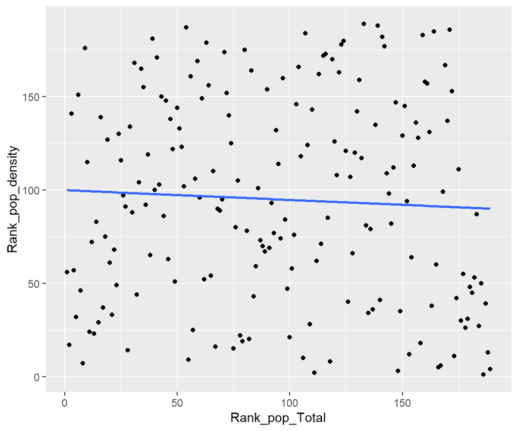

```r
df_pop %>%
  ggplot(aes(x = Rank_pop_Total, y = Rank_pop_density)) +
  geom_point() +
  geom_smooth(method = "lm", se = FALSE)
```